# ICT_LIS_661_Project_2_Copy

Jonathan Jimenez

2022-10-16

# Welcome to Project 2!

Before moving on, please make a copy of this file and rename it in a way that makes a clear distinction between the original file and the file you’ll eventually submit.

> Under the headers below, I’ll provide you with certain instructions, all of them formatted as blockquotes, like this paragraph is. Underneath each set of blockquoted instructions, you should write a (non-blockquoted) response to any questions I ask and fill out any code chunks as I instruct you. At the very end of this document, I’ll provide instructions for *knitting* and submitting the `.Rmd` to Canvas.

## Project 2, Part 1: Your Dataset [8 points]

> For this project, you will need to identify a dataset with at least 100 observations and 5 variables. A dataset with at least 1,000 observations and 10 variables would be even better—but not necessary. It is fine for this to be a dataset that you have used previously in this class. This does not need to be a publicly available dataset, but please ensure that you can use the dataset legally and ethically. Store the data somewhere in your GitHub repository for this class.

> In the code chunk below, please load the dataset into this document. (Keep in mind that you can—and may need to—install and load packages as part of this or any other code chunk). [2 points]

Part one was not that difficult as we have been practicing this bit of code since the beginning of the class. At this point, it has become second nature to know how to read all types of data sets. The user can interpret their data set with ease using str().

```r
library(tidyverse)
library(here)
```

```r
library(ggplot2)

game <- read_csv(here("project_2","imdb_video_game_rating.csv"))
```

[output not shown]

```r
game$year <- as.integer(game$year)
str(game)
```

```
## spec_tbl_df [12,635 × 8] (S3: spec_tbl_df/tbl_df/tbl/data.frame)
##  $ ...1     : num [1:12635] 0 1 2 3 4 5 6 7 8 9 ...
##  $ title    : chr [1:12635] "The Last of Us: Part I" "Red Dead Redemption II" "The Witcher 3: Wild Hunt - Blood and Wine" "The Witcher 3: Wild Hunt" ...
##  $ year     : int [1:12635] 2022 2018 2016 2015 2013 2021 2018 2019 1998 1998 ...
##  $ genre    : chr [1:12635] "Action, Adventure, Drama" "Action, Adventure, Crime" "Action, Adventure, Drama" "Action, Adventure, Drama" ...
##  $ rating   : num [1:12635] 9.8 9.7 9.7 9.7 9.7 9.7 9.6 9.6 9.6 9.6 ...
##  $ votes    : num [1:12635] 601 36441 7610 26328 61103 ...
##  $ directors: chr [1:12635] "Matthew Gallant, Bruce Straley" "Missing" "Konrad Tomaszkiewicz" "Konrad Tomaszkiewicz" ...
##  $ plot     : chr [1:12635] "Experience the emotional storytelling and unforgettable characters in The Last of Us, winner of over 200 Game o"| __truncated__ "Amidst the decline of the Wild West at the turn of the 20th century, outlaw Arthur Morgan and his gang struggle"| __truncated__ "Geralt is …
##  - attr(*, "spec")=
##   .. cols(
##   ..   ...1 = col_double(),
##   ..   title = col_character(),
##   ..   year = col_character(),
##   ..   genre = col_character(),
##   ..   rating = col_double(),
##   ..   votes = col_number(),
##   ..   directors = col_character(),
##   ..   plot = col_character()
##   .. )
##  - attr(*, "problems")=<externalptr>
```

```r
class(game)
```

```
## [1] "spec_tbl_df" "tbl_df"      "tbl"         "data.frame"
```

```r
game
```

```
## # A tibble: 12,635 × 8
##     ...1 title                             year genre rating votes direc…¹ plot
##    <dbl> <chr>                            <int> <chr>  <dbl> <dbl> <chr>   <chr>
##  1     0 The Last of Us: Part I            2022 Acti…    9.8   601 Matthe… Expe…
##  2     1 Red Dead Redemption II            2018 Acti…    9.7 36441 Missing Amid…
##  3     2 The Witcher 3: Wild Hunt - Bloo…  2016 Acti…    9.7  7610 Konrad… Gera…
##  4     3 The Witcher 3: Wild Hunt          2015 Acti…    9.7 26328 Konrad… A mo…
##  5     4 The Last of Us                    2013 Acti…    9.7 61103 Neil D… In a…
##  6     5 Mass Effect: Legendary Edition    2021 Acti…    9.7  1628 Casey … A co…
##  7     6 God of War                        2018 Acti…    9.6 26507 Cory B… Afte…
##  8     7 Persona 5 Royal                   2019 Acti…    9.6  1214 Daiki … A gr…
##  9     8 The Legend of Zelda: Ocarina of…  1998 Acti…    9.6  9576 Eiji A… A yo…
## 10     9 Metal Gear Solid                  1998 Acti…    9.6 11809 Hideo … A cr…
## # … with 12,625 more rows, and abbreviated variable name ¹directors
```

> Now that you’ve loaded the dataset, please tell me some about it. Does it have a title? If not, what title would you give it? What reference or citation information (including a public URL, if applicable) can you provide about the dataset? Who created the dataset and when? How did they create it? [2 points]

Link to open data set - https://www.kaggle.com/datasets/muhammadadiltalay/imdb-video-games

> What is your interest in this dataset? In general terms, what would you like to know about it? More specifically, what are some possible research questions that you could ask? [2 points]

I have always been interested in video games, and this assignment allows me to work on data that I have an interest in while advancing my technical skills as well. The data set has information on all types of video games created with a rating. By analyzing and modifying the data, I am hoping to find out what games are the most and least popular according to genre. That way, when I am deciding which games to play next, I will only be selecting from the “cream of the crop”.

Does the overall rating of games rise or decline with time? Are the best-rated games made in the past or present? What year had the best rated games? Does a cretin genre average better scores than others? Does genre have an impact on ratings? What genre has the highest rating? Which game has the highest rating?

> As needed, perform any data cleaning (including “tidying”) on the text in the code chunk below. [2 points]

In this section of the project, I only had one issue. That issue was that when I was tying up the data, there was a column called “…1”. This column was included in the data set to indicate “observation #” an observation was on. This confused me as the tidied data looked a bit funny and not right. After some digging around, I found out that it was part of the data set, so I simply did “select(-)”. This syntax removes/ignores that whole column of observations. Another step that I took in this chunk was turning the “year” variable from a char to an int type. allowing tiding fiction to work with the data set.

```r
game_fil <- game %>%
  select(-genre)%>%
select(-directors)%>%
  select(-plot)%>%
  select(-...1)
game_fil
```

```
## # A tibble: 12,635 × 4
##    title                                      year rating votes
##    <chr>                                     <int>  <dbl> <dbl>
##  1 The Last of Us: Part I                     2022    9.8   601
##  2 Red Dead Redemption II                     2018    9.7 36441
##  3 The Witcher 3: Wild Hunt - Blood and Wine  2016    9.7  7610
##  4 The Witcher 3: Wild Hunt                   2015    9.7 26328
##  5 The Last of Us                             2013    9.7 61103
##  6 Mass Effect: Legendary Edition             2021    9.7  1628
##  7 God of War                                 2018    9.6 26507
##  8 Persona 5 Royal                            2019    9.6  1214
##  9 The Legend of Zelda: Ocarina of Time       1998    9.6  9576
## 10 Metal Gear Solid                           1998    9.6 11809
## # … with 12,625 more rows
```

```r
#Making Numeric columns
game_add <-game %>%
mutate(yearplusrating = year + rating) %>%  mutate(yeartimesrating = year * rating)
game_add
```

```
## # A tibble: 12,635 × 10
##     ...1 title             year genre rating votes direc…¹ plot  yearp…² yeart…³
##    <dbl> <chr>            <int> <chr>  <dbl> <dbl> <chr>   <chr>   <dbl>   <dbl>
##  1     0 The Last of Us:…  2022 Acti…    9.8   601 Matthe… Expe…   2032.  19816.
##  2     1 Red Dead Redemp…  2018 Acti…    9.7 36441 Missing Amid…   2028.  19575.
##  3     2 The Witcher 3: …  2016 Acti…    9.7  7610 Konrad… Gera…   2026.  19555.
##  4     3 The Witcher 3: …  2015 Acti…    9.7 26328 Konrad… A mo…   2025.  19546.
##  5     4 The Last of Us    2013 Acti…    9.7 61103 Neil D… In a…   2023.  19526.
##  6     5 Mass Effect: Le…  2021 Acti…    9.7  1628 Casey … A co…   2031.  19604.
##  7     6 God of War        2018 Acti…    9.6 26507 Cory B… Afte…   2028.  19373.
##  8     7 Persona 5 Royal   2019 Acti…    9.6  1214 Daiki … A gr…   2029.  19382.
##  9     8 The Legend of Z…  1998 Acti…    9.6  9576 Eiji A… A yo…   2008.  19181.
## 10     9 Metal Gear Solid  1998 Acti…    9.6 11809 Hideo … A cr…   2008.  19181.
## # … with 12,625 more rows, and abbreviated variable names ¹directors,
## #   ²yearplusrating, ³yeartimesrating
```

```r
  tidy_game <- game_fil %>%
  pivot_longer(names_to = "Movie Variables", values_to = "Values", cols = -title, names_transform = list(year = as.numeric))
  tidy_game
```

```
## # A tibble: 37,905 × 3
##    title                                     `Movie Variables`  Values
##    <chr>                                     <chr>               <dbl>
##  1 The Last of Us: Part I                    year               2022
##  2 The Last of Us: Part I                    rating                9.8
##  3 The Last of Us: Part I                    votes               601
##  4 Red Dead Redemption II                    year               2018
##  5 Red Dead Redemption II                    rating                9.7
##  6 Red Dead Redemption II                    votes             36441
##  7 The Witcher 3: Wild Hunt - Blood and Wine year               2016
##  8 The Witcher 3: Wild Hunt - Blood and Wine rating                9.7
##  9 The Witcher 3: Wild Hunt - Blood and Wine votes              7610
## 10 The Witcher 3: Wild Hunt                  year               2015
## # … with 37,895 more rows
```

## Project 2, Part 2: Descriptive Statistics [12 points]

> In the code chunk below, write code to determine the number of observations in the dataset. As is typical for R, there are a number of ways to do this—*how* you do so is less important than *that* you do so. [2 points]

I did not use my tidy data set in this part of the project as it did not work as well as when I did it with non-tidied data. In this section, I chose to “count” and “tally” the number of observations with my own data set. This chunk counts before tidying the data.

```r
game %>% count(year)
```

```
## # A tibble: 59 × 2
##     year     n
##    <int> <int>
##  1  1948     1
##  2  1952     1
##  3  1958     1
##  4  1962     1
##  5  1969     2
##  6  1970     1
##  7  1971     4
##  8  1972    16
##  9  1973     6
## 10  1974     6
## # … with 49 more rows
```

```r
game %>% count(votes)
```

```
## # A tibble: 1,638 × 2
##    votes     n
##    <dbl> <int>
##  1     5   155
##  2     6   297
##  3     7   400
##  4     8   381
##  5     9   391
##  6    10   341
##  7    11   317
##  8    12   319
##  9    13   270
## 10    14   249
## # … with 1,628 more rows
```

```r
game %>% count(...1)
```

```
## # A tibble: 12,635 × 2
##     ...1     n
##    <dbl> <int>
##  1     0     1
##  2     1     1
##  3     2     1
##  4     3     1
##  5     4     1
##  6     5     1
##  7     6     1
##  8     7     1
##  9     8     1
## 10     9     1
## # … with 12,625 more rows
```

```r
game %>% group_by(genre) %>% tally()
```

```
## # A tibble: 391 × 2
##    genre                            n
##    <chr>                        <int>
##  1 Action                        1402
##  2 Action, Adventure              381
##  3 Action, Adventure, Comedy      440
##  4 Action, Adventure, Crime       168
##  5 Action, Adventure, Drama       200
##  6 Action, Adventure, Family      430
##  7 Action, Adventure, Fantasy    1329
##  8 Action, Adventure, Game-Show     1
##  9 Action, Adventure, History      42
## 10 Action, Adventure, Horror      123
## # … with 381 more rows
```

> In the code chunk below, write code to list the variables included in the dataset. Then, below the code chunk, list and explain 5-10 of the most important quantitative variables. (The quantitative part will become important in the next step!)

```r
#Not Added
str(game)
```

```
## spec_tbl_df [12,635 × 8] (S3: spec_tbl_df/tbl_df/tbl/data.frame)
##  $ ...1     : num [1:12635] 0 1 2 3 4 5 6 7 8 9 ...
##  $ title    : chr [1:12635] "The Last of Us: Part I" "Red Dead Redemption II" "The Witcher 3: Wild Hunt - Blood and Wine" "The Witcher 3: Wild Hunt" ...
##  $ year     : int [1:12635] 2022 2018 2016 2015 2013 2021 2018 2019 1998 1998 ...
##  $ genre    : chr [1:12635] "Action, Adventure, Drama" "Action, Adventure, Crime" "Action, Adventure, Drama" "Action, Adventure, Drama" ...
##  $ rating   : num [1:12635] 9.8 9.7 9.7 9.7 9.7 9.7 9.6 9.6 9.6 9.6 ...
##  $ votes    : num [1:12635] 601 36441 7610 26328 61103 ...
##  $ directors: chr [1:12635] "Matthew Gallant, Bruce Straley" "Missing" "Konrad Tomaszkiewicz" "Konrad Tomaszkiewicz" ...
##  $ plot     : chr [1:12635] "Experience the emotional storytelling and unforgettable characters in The Last of Us, winner of over 200 Game o"| __truncated__ "Amidst the decline of the Wild West at the turn of the 20th century, outlaw Arthur Morgan and his gang struggle"| __truncated__ "Geralt is …
##  - attr(*, "spec")=
##   .. cols(
##   ..   ...1 = col_double(),
##   ..   title = col_character(),
##   ..   year = col_character(),
##   ..   genre = col_character(),
##   ..   rating = col_double(),
##   ..   votes = col_number(),
##   ..   directors = col_character(),
##   ..   plot = col_character()
##   .. )
##  - attr(*, "problems")=<externalptr>
```

```r
ls(game)
```

```
## [1] "directors" "genre"     "plot"      "rating"    "title"     "votes"
## [7] "year"
```

```r
#Added
str(game_add)
```

```
## tibble [12,635 × 10] (S3: tbl_df/tbl/data.frame)
##  $ ...1           : num [1:12635] 0 1 2 3 4 5 6 7 8 9 ...
##  $ title          : chr [1:12635] "The Last of Us: Part I" "Red Dead Redemption II" "The Witcher 3: Wild Hunt - Blood and Wine" "The Witcher 3: Wild Hunt" ...
##  $ year           : int [1:12635] 2022 2018 2016 2015 2013 2021 2018 2019 1998 1998 ...
##  $ genre          : chr [1:12635] "Action, Adventure, Drama" "Action, Adventure, Crime" "Action, Adventure, Drama" "Action, Adventure, Drama" ...
##  $ rating         : num [1:12635] 9.8 9.7 9.7 9.7 9.7 9.7 9.6 9.6 9.6 9.6 ...
##  $ votes          : num [1:12635] 601 36441 7610 26328 61103 ...
##  $ directors      : chr [1:12635] "Matthew Gallant, Bruce Straley" "Missing" "Konrad Tomaszkiewicz" "Konrad Tomaszkiewicz" ...
##  $ plot           : chr [1:12635] "Experience the emotional storytelling and unforgettable characters in The Last of Us, winner of over 200 Game o"| __truncated__ "Amidst the decline of the Wild West at the turn of the 20th century, outlaw Arthur Morgan and his gang struggle"| __truncated__ "Gera…
##  $ yearplusrating : num [1:12635] 2032 2028 2026 2025 2023 ...
##  $ yeartimesrating: num [1:12635] 19816 19575 19555 19546 19526 ...
```

```r
ls(game_add)
```

```
## [1] "directors"       "genre"           "plot"            "rating"
## [5] "title"           "votes"           "year"            "yearplusrating"
## [9] "yeartimesrating"
```

> In the code chunk below, calculate descriptive statistics (including mean, median, variance, and standard deviation) for each of the variables you listed above. Then, below the code chunk, describe what those descriptive statistics tell you about those variables. [3 points]

During this part of the assignment, I did not have much experience besides implementing the right variables and standard deviation syntax. For example, I simply looked at the previous assignment that we did and inserted my corresponding variables with the standard deviation function added as well.

```r
game_add %>% group_by(genre) %>% summarize_at(vars( rating, votes, year, ...1, yeartimesrating, yearplusrating), list(~mean(.), ~median(.), ~sd(.)))
```

```
## # A tibble: 391 × 19
##    genre ratin…¹ votes…² year_…³ ...1_…⁴ yeart…⁵ yearp…⁶ ratin…⁷ votes…⁸ year_…⁹
##    <chr>   <dbl>   <dbl>   <dbl>   <dbl>   <dbl>   <dbl>   <dbl>   <dbl>   <dbl>
##  1 Acti…    6.50    45.4     NA    7615.     NA      NA     6.7     19        NA
##  2 Acti…    6.83   150.      NA    6727.     NA      NA     7       31        NA
##  3 Acti…    7.19   418.      NA    5566.     NA      NA     7.4     90.5      NA
##  4 Acti…    7.21  1701.      NA    5698.     NA      NA     7.35   248        NA
##  5 Acti…    7.86  2378.    2007.   3521.  15781.   2015.    7.9    146.     2006
##  6 Acti…    7.04   438.      NA    6190.     NA      NA     7.2    102.       NA
##  7 Acti…    7.34   708.      NA    5079.     NA      NA     7.5     88        NA
##  8 Acti…    4.4      8     2006   12061    8826.   2010.    4.4      8      2006
##  9 Acti…    7.12  2230.    2009.   5741.  14293.   2016.    7.25   239      2012
## 10 Acti…    7.17  1066.      NA    5648.     NA      NA     7.3    151        NA
## # … with 381 more rows, 9 more variables: ...1_median <dbl>,
## #   yeartimesrating_median <dbl>, yearplusrating_median <dbl>, rating_sd <dbl>,
## #   votes_sd <dbl>, year_sd <dbl>, ...1_sd <dbl>, yeartimesrating_sd <dbl>,
## #   yearplusrating_sd <dbl>, and abbreviated variable names ¹rating_mean,
## #   ²votes_mean, ³year_mean, ⁴...1_mean, ⁵yeartimesrating_mean,
## #   ⁶yearplusrating_mean, ⁷rating_median, ⁸votes_median, ⁹year_median
```

> Consider further questions that you have about the data and how visualization could help you answer those questions. In the code chunk below, pick one or more of the variables in your dataset and visualize them. Then, below the code chunk, describe what you were trying to learn about the data, what kind of plot you chose, why that plot is important for what you were trying to learn, and what the plot showed about the data. [4 points]

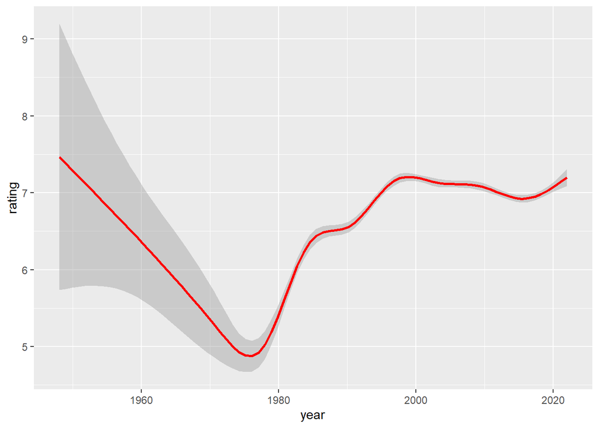

```r
#Does the overall rating of games rise or decline with time?
#Are the best-rated games made in the past or present?
#What year had the best rated games?
  ggplot(data = game_add) +
    geom_smooth(mapping = aes(x = year, y = rating), color = "red", show.legend = FALSE)
```